# Calculus5 曲線・曲面 Curved line and surface

ryamada

2017年1月22日

# 1 曲線の長さ Length of curve

$$y = f(x) = x + \frac{1}{2}x^2$$

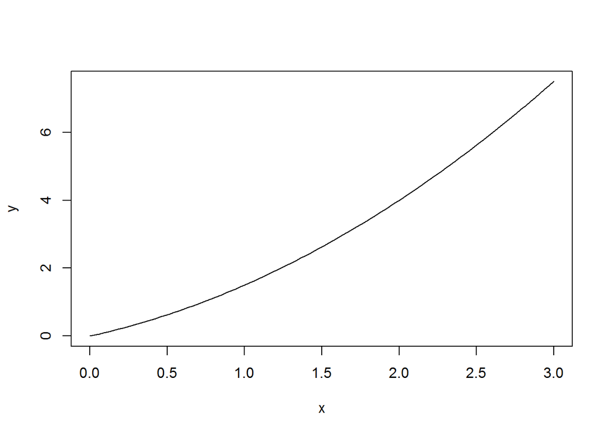

```r
x <- seq(from=0,to=3,length=100)
y <- x+ 1/2*x^2
plot(x,y,type="l")
```

$$\frac{d}{dx}f(x) = 1 + x$$
微分すると、単位x増分当たりのyの増加量がわかる。それらは、微小直角三角形。

Differentiation gives increase of y along with unit increase in x. They are two edges of a right triangle.

三角形 (x,y) ,(x+dx,y),(x+dx,y+dy)は直角三角形の3頂点。 曲線の長さはこの三角形の斜辺の積分

(x,y) ,(x+dx,y),(x+dx,y+dy) are three vertices of a right triangle. The length of curve is the integral of the obliques.

$$\int_{0}^3 \sqrt{dx^2+dy^2} = \int_0^3 \sqrt{(\frac{dx}{dx})^2+(\frac{dy}{dx})^2}dx = \sqrt{1+(\frac{dy}{dx})^2}dx \\$$

積分できるのか？ Can we integrate this?

Mathematicaを使えば…。

Check Mathematica http://www.wolframalpha.com/examples/Math.html for “Calculus AND ANALYSIS” and http://d.hatena.ne.jp/ryamada22/20170128

積分できるかできないかわからなくても近似計算はできる。

Even when the integral is not easy shape, computational calculation is possible.

```r
integrate(function(x){(2+2*x+x^2)^(1/2)},0,3)
```

```
## 8.145774 with absolute error < 9e-14
```

# 2 Exercise 1

## 2.1 Exercise 1-1

# 3 曲線のパラメタ表示 Parameteric expression of curve.

$$x = \cos{t}\\
y = \sin{t}\\
t \in [0,2\pi)$$

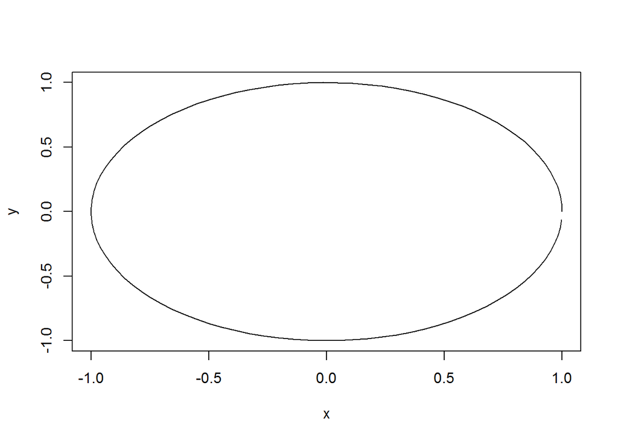

```r
t <- seq(from=0,to=1,length=100)*2*pi
t <- t[-length(t)]
x <- cos(t)
y <- sin(t)
plot(x,y,type="l")
```

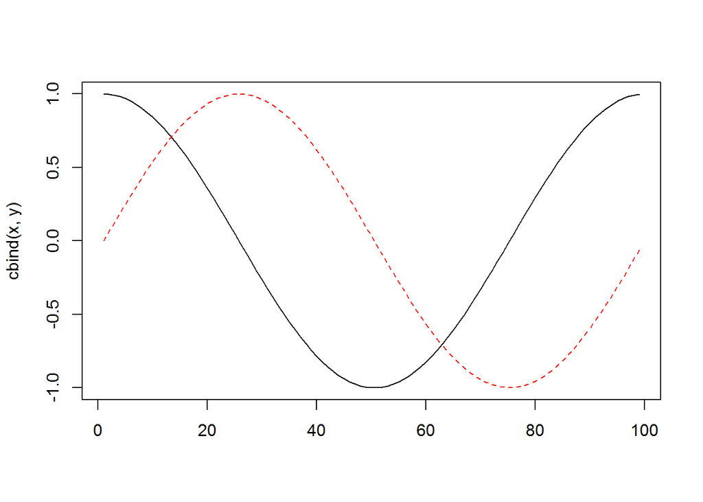

```r
matplot(cbind(x,y),type="l")
```

$$L(\tau) = \int_0^\tau \sqrt{(\frac{dx}{dt})^2 + (\frac{dy}{dt})^2} dt$$

$$\frac{dx}{dt} = -\sin{t}\\
\frac{dy}{dt} = \cos{t}\\
L(\tau) = \int_0^\tau \sqrt{(\sin{t})^2 + (\cos{t})^2} dt\\
=\int_0^\tau 1 dt\\
=[t]^\tau_0 = \tau$$

## 3.1 同じ軌道、スピードが違う Same trajectory but different speed

$$x = \cos{t^2}\\
y = \sin{t^2}\\
t \in [0,\sqrt{2\pi})$$

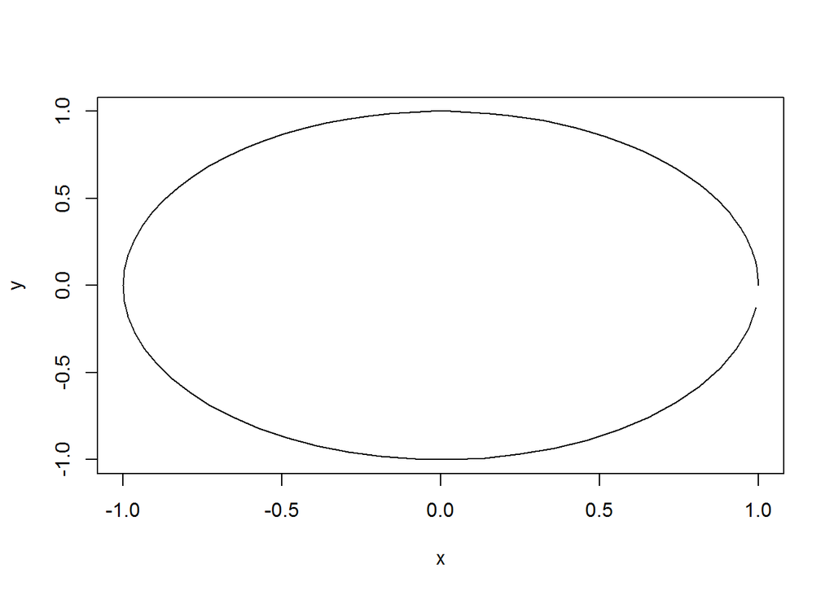

```r
t <- seq(from=0,to=1,length=100)*sqrt(2*pi)
t <- t[-length(t)]
x <- cos(t^2)
y <- sin(t^2)
plot(x,y,type="l")
```

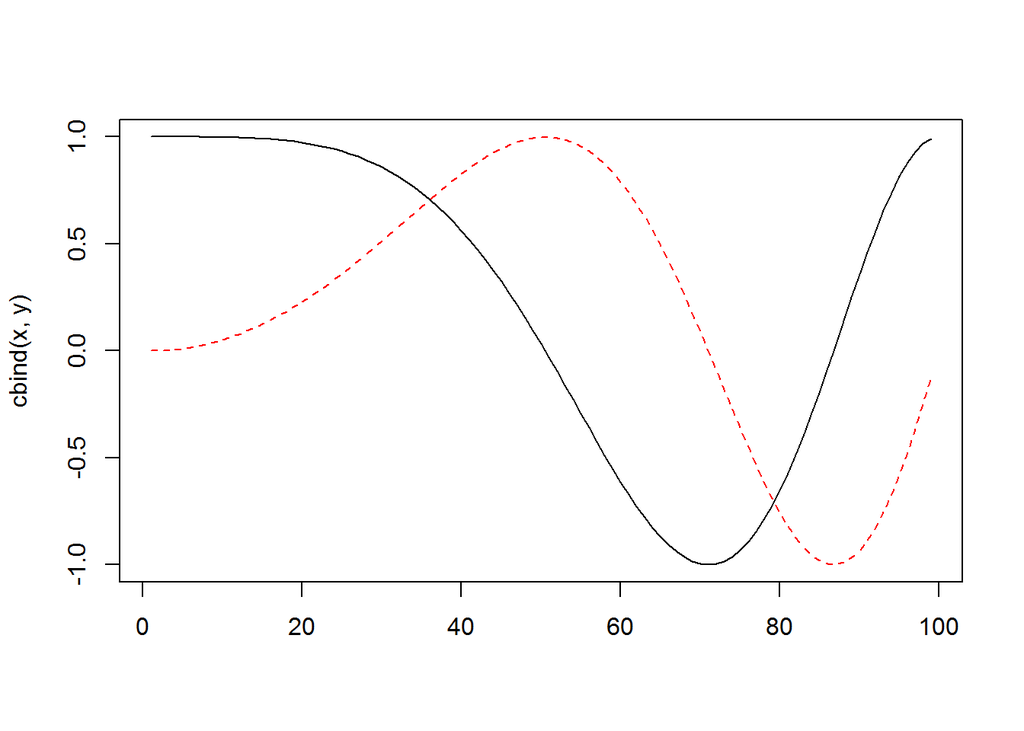

```r
matplot(cbind(x,y),type="l")
```

$$L(\tau) = \int_0^\tau \sqrt{(\frac{dx}{dt})^2+(\frac{dy}{dt})^2}dt\\
= \int_0^\tau \sqrt{(-2t\sin(t^2))^2+(2t\cos(t^2))^2}dt\\
= \int_0^\tau 2t \sqrt{\sin^2{(t^2)}+\cos^2{(t^2)}} dt\\
= \int_0^\tau 2t dt\\
= [t^2]_0^\tau\\
= \tau^2$$

# 4 Exercise 2

## 4.1 Exercise 2-1

曲線
$$x = \cos{t}\\
y = \sin{t}\\
t \in [0,2\pi)$$
を描き、その曲線の上に適当に多数の点を取り、その点での進行方向ベクトル$(\frac{dx}{dt},\frac{dy}{dt})$を描け。

Draw the curve and put its speed vectors $(\frac{dx}{dt},\frac{dy}{dt})$ on many points on the curve.

## 4.2 Exercise 2-2

$$x = \cos{t^2}\\
y = \sin{t^2}\\
t \in [0,\sqrt{2\pi})$$
について同様のことをせよ。

Do the same for this parameterization.

## 4.3 Exercise 2-3

3次元空間の曲線
$$x = r\cos{t}\\
y = r\sin{t}\\
z = r^2\\
r = 0.1t+0.1\\
t \in [0,100]$$

```r
t <- seq(from=0,to=1,length=1000)*100
r <- 0.1*t+0.1
x <- r*cos(t)
y <- r*sin(t)
z <- r^2
plot3d(x,y,z,type="l")
```

[interactive chart not shown]

You must enable Javascript to view this page properly.

$\frac{dx}{dt},\frac{dy}{dt},\frac{dz}{dt}$を計算し、曲線の長さとしてその積分をRのintegrate()関数を使って計算せよ。

This is a curve in 3D space. Calculate $\frac{dx}{dt},\frac{dy}{dt},\frac{dz}{dt}$ and calculate the length of curve with R’s integrate() function.

また、曲線の長さを折れ線の長さの集まりとして

```
t <- seq(from=0,to=1,length=n)*100
```

$n=10,100,1000,10000,100000$について計算せよ。

For multiple n values, calculate the length of broken lines that approximate the curve.

# 5 単位円の面積 Area of a unit circle.

単位円の面積は、The following is the 1/4 of unit circle’s area.

$$y = \sqrt{(1-x^2)}\\
y = 0 \\
x \in [0,1]$$
の4倍として求めることができる。

$$4 \int_0^1 \sqrt{(1-x^2)}dx$$

この積分を解くのは難しい。 It’s no easy to solve this.

```r
integrate(function(x){4*sqrt(1-x^2)},0,1)
```

```
## 3.141593 with absolute error < 0.00016
```

微小底辺$dl$を円周上に持ち、高さが半径1の三角形の和として計算することもできる。

中心からの半径方向を$\theta \in [0,2\pi)$とすれば

The area of circle is the sum of small triangles whose base lines are small arcs $dl$ of the circle and whose hight are the radius. The directions of the triangles are parameterized as $\theta \in [0,2\pi)$.

$$\int_0^{2\pi} \frac{1}{2}\times dl \\
dl = \sqrt{(\frac{dx}{d\theta})^2+(\frac{dy}{d\theta})^2}d\theta = d\theta$$
これは、円周の長さ$2\pi$を底辺の長さとする三角形の面積。

It corresponds to the area of triangle whose base is a whole circle.

別の方法は円を半径が0から1に変化する円のあつまりとみなすものである。

Another way is to consider the area of circle as the sum of cicles with radius ranging from 0 to 1.

半径$r$での微小面積は$2\pi r \times dr$.

The small area attached to the circle with radius r is $2\pi r \times dr$.

$$\int_0^1 2\pi r dr = 2\pi \int_0^1 r dr = 2\pi [\frac{1}{2}r^2]^1_0 = \pi$$
# 曲面 Curved surface

以下のような曲面の面積はどうなるか？

How do we approach to the area of the curved surface as below?

$$z = \sin{x}+\cos{y}\\
x, y \in [-5,5]$$

```r
x <- y <- seq(from=-1,to=1,length=100) * 5
xy <- as.matrix(expand.grid(x,y))
z <- sin(xy[,1])+cos(xy[,2])
xlim <- max(xy[,1])-min(xy[,1])
ylim <- max(xy[,2])-min(xy[,2])
zlim <- max(z)-min(z)
plot3d(xy[,1],xy[,2],z,aspect=c(xlim,ylim,zlim))
```

[interactive chart not shown]

You must enable Javascript to view this page properly.

(x,y),(x+dx,y),(x,y+dy),(x+dx,x+dy)が作る「斜面」の面積$dS$を足し合わせる。

Small areas that are slopes over (x,y),(x+dx,y),(x,y+dy),(x+dx,x+dy), $dS$, should be summed up.

これを斜めになった平行四辺形の面積とみなす。 They are considered small parallelograms.

平行四辺形の第1の辺は$(x,y,z)$と$(x+dx,y,z+\frac{\partial x}{\partial z}dx)$とが作るベクトル。 第2の辺は$(x,y,z)$と$(x,y+dy+z+\frac{\partial y}{\partial z}dy)$。

The parallelogram’s two edges are; one connecting $(x,y,z)$と$(x+dx,y,z+\frac{\partial x}{\partial z}dx)$ and and the other connecting $(x,y,z)$ and $(x,y+dy+z+\frac{\partial y}{\partial z}dy)$.

2つのベクトルは They are:
$$v_1 = (dx,0,\frac{\partial z}{\partial x}dx)\\
v_2 = (0,dy,\frac{\partial z}{\partial y}dy)$$

2つのベクトル$v_1,v_2$が作る平行四辺形の面積は The area of parallelogram is;

$$dS = ||v_1||v_2|\sin{\theta}|$$
$$\cos{\theta} = \frac{(v_1,v_2)}{|v_1||v_2|}$$
ただし、$(v_1,v_2)$は内積。 where $(v_1,v_2)$ is inner product.

したがって Therefore,

$$dS = ||v_1||v_2|\sqrt{1-(\frac{(v_1,v_2)}{|v_1||v_2|})^2}|\\
= \sqrt{|v_1|^2|v_2|^2 - (v_1,v_2)^2}$$

ここで Using
$$|v_1|^2 = (1+(\frac{\partial z}{\partial x})^2dx^2\\
|v_2|^2 = (1+(\frac{\partial z}{\partial y})^2dy^2\\
(v_1,v_2) =(\frac{\partial z}{\partial x}\frac{\partial z}{\partial y})^2dxdy$$

以上より、Then,
$$dS = \sqrt{1+(\frac{\partial z}{\partial x})^2+(\frac{\partial z}{\partial y})^2} dxdy$$

## 5.1 Exercise 3

### 5.1.1 Exercise 3-1

2つの式を比較せよ。

Compare two formulas.

$$\int_{0}^3 \sqrt{dx^2+dy^2} = \int_0^3 \sqrt{(\frac{dx}{dx})^2+(\frac{dy}{dx})^2}dx = \sqrt{1+(\frac{dy}{dx})^2}dx \\$$

$$dS = \sqrt{1+(\frac{\partial z}{\partial x})^2+(\frac{\partial z}{\partial y})^2} dxdy$$

## 5.2 曲面の前に、平面 Before using this to curved surface, apply it to the flat one.

$$z = ax + by + c$$

$$\frac{\partial z}{\partial x}=a\\
\frac{\partial z}{\partial y}=b\\
dS = \sqrt{1+a^2+b^2}dxdy \\
\int_{x_0}^{x_1} \int_{y_0}^{y_1} dS dxdy = \sqrt{1+a^2+b^2} \times (x_1-x_0)(y_1-y_0)$$
単なる、平行四辺形の面積。

Simple parallelogram’s area.

## 5.3 単位球面積 Surface area of unit sphere.

$$dS = \sqrt{1+(\frac{\partial z}{\partial x})^2+(\frac{\partial z}{\partial y})^2} dxdy\\
\frac{\partial z}{\partial x}= \frac{1}{2}\frac{-2x}{\sqrt{1-(x^2+y^2)}}\\
\frac{\partial z}{\partial y} = \frac{1}{2}\frac{-2y}{\sqrt{1-(x^2+y^2)}}\\$$

$$dS = \sqrt{1+\frac{x^2}{1-(x^2+y^2)}+\frac{y^2}{1-(x^2+y^2)}}dxdy\\
= \sqrt{\frac{1}{1-(x^2+y^2)}}dxdy$$

$$S = \int_{x^2+y^2 \le 1} dS = \int_{x^2+y^2 \le 1} \sqrt{\frac{1}{1-(x^2+y^2)}}dxdy$$

これは解けないが、うまくパラメタ表示を変えることで解けるようにできる。

This is not easy but converting to different parameterization, then it can be.

$$x = r \cos{\theta}\\
y = r \sin{\theta}\\
0 \le r \le 1\\
0 \le \theta \le 2\pi\\$$

Small area should be changed accordingly.

$$dr \times (r \times d\theta)$$
したがって$dxdy$に相当するのは$rdrd\theta$

Means $dxdy$ is converted to $rdrd\theta$.

ゆえに
$$S = \int_{x^2+y^2 \le 1} \sqrt{\frac{1}{1-(x^2+y^2)}}dxdy\\
= \int_{0 \le r \le 1, 0\le \theta \le 2\pi} \sqrt{\frac{1}{1-r^2(\cos^2\theta + \sin^2{\theta})}}rdrd\theta\\
=\int_0^{2\pi} 1 d\theta \int_0^1 r\sqrt{\frac{1}{1-r^2}}dr$$

$$\frac{d}{dr} \sqrt{1-r^2} = \frac{1}{2}(-2r) \sqrt{\frac{1}{1-r^2}}\\
= -r\sqrt{\frac{1}{1-r^2}}$$

したがって
$$S = 2\pi$$
これは球の上半分であるから、球面全体の表面積は、$4\pi$.

This is the upper half’s area, therefore the are of unit sphere is $4\pi$.

## 5.4 曲面 Curverd surface

$$z = \sin{x}+\cos{y}\\
x, y \in [-5,5]$$

```r
x <- y <- seq(from=-1,to=1,length=100) * 5
xy <- as.matrix(expand.grid(x,y))
z <- sin(xy[,1])+cos(xy[,2])
xlim <- max(xy[,1])-min(xy[,1])
ylim <- max(xy[,2])-min(xy[,2])
zlim <- max(z)-min(z)
plot3d(xy[,1],xy[,2],z,aspect=c(xlim,ylim,zlim))
```

[interactive chart not shown]

You must enable Javascript to view this page properly.

2つのベクトルは The vecors are;
$$(dx,0,-\sin{x}dx)\\
(0,dy,\cos{y}dy)$$

したがって Then

$$dS = ||v_1||v_2|\sqrt{1-(\frac{(v_1,v_2)}{|v_1||v_2|})^2}|\\
= \sqrt{|v_1|^2|v_2|^2 - (v_1,v_2)^2}$$

ここで Using
$$|v_1|^2 = (1+\sin^2{x})dx^2\\
|v_2|^2 = (1+\cos^2{y})dy^2\\
(v_1,v_2) = -\sin{x}\cos{y}dxdy$$

以上より、Therefere
$$dS = \sqrt{(1+\sin^2{x})(1+\cos^2{y})-\sin^2{x}\cos^2{y}} dxdy
= \sqrt{1+(\sin^2{x}+\cos^2{y})}dxdy$$

解けないけれど、計算機的には計算できる。 Computationally calculable.

## 5.5 Exercise 4

## 5.6 Exercise 4-1

Mathematicaのサイトを使ってこの面積を計算せよ。

Calculate the area using Mathematica’s site.